# pyTorch-tutorial-notebook

```python
import torch
import torch.utils.data as Data
import torch.nn as nn
import torch.optim as optim
import torch.nn.functional as F
import matplotlib.pyplot as plt
import numpy as np
from torchvision import datasets, transforms


%matplotlib inline
```

Check the version of pytorch that you have installed.  
Make sure that you refer the correct version of the online documentation at https://pytorch.org/docs/versions.html

```python
print(torch.__version__)
```

```
1.7.1
```

# Tensors

Tensors are object analogous to but more general than a vector, represented by an array of components that are functions of the coordinates of a space. Different intuitive explanations of tensor are found here https://www.quora.com/What-is-a-tensor

A PyTorch Tensor is conceptually identical to a numpy array: a Tensor is an n-dimensional array, and PyTorch provides many functions for operating on these Tensors. However unlike numpy arrays, PyTorch Tensors can utilize GPUs to accelerate their numeric computations. To run a PyTorch Tensor on GPU, you simply need to cast it to a new datatype.

Lets start with basic operations on torch tensor

#### Constructing Tensors

```python
# Construct an uninitialized 5x3 matrix
x_empty = torch.empty(5, 3)  # similar to np.empty
print('Empty tensor:\n',x_empty)
```

```
Empty tensor:
 tensor([[-3.1819e+09,  4.5736e-41, -3.1819e+09],
        [ 4.5736e-41,         nan,  0.0000e+00],
        [ 7.6194e+31,  1.5564e+28,  4.7984e+30],
        [ 6.2121e+22,  1.8370e+25,  1.4603e-19],
        [ 1.6795e+08,  4.7423e+30,  4.7393e+30]])
```

```python
# Construct a matrix filled zeros and of dtype long:
x_zeros = torch.zeros(5, 3, dtype=torch.long) # similar to np.zeros
print('Zero tensor:\n',x_zeros)
```

```
Zero tensor:
 tensor([[0, 0, 0],
        [0, 0, 0],
        [0, 0, 0],
        [0, 0, 0],
        [0, 0, 0]])
```

```python
# Construct a tensor directly from data
x_list = torch.tensor([5.5, 3])
print('Tensor from list:\n',x_list)
```

```
Tensor from list:
 tensor([5.5000, 3.0000])
```

#### Convert numpy array to torch tensor or vice versa

```python
np_data = np.arange(6).reshape((2, 3))
torch_data = torch.from_numpy(np_data) # Numpy Array -> Torch Tensor

tensor2array = torch_data.numpy()      # Torch Tensor -> Numpy Array

print(
    '\nnumpy array:\n', np_data, '\n',
    '\nOutput of numpy array -> tensor conversion:\n', torch_data, '\n',
    '\nOutput of tensor -> numpy array conversion:\n', tensor2array,'\n',
)
```

```
numpy array:
 [[0 1 2]
 [3 4 5]]

Output of numpy array -> tensor conversion:
 tensor([[0, 1, 2],
        [3, 4, 5]])

Output of tensor -> numpy array conversion:
 [[0 1 2]
 [3 4 5]]
```

```python
# matrix multiplication
data = [[1,2], [3,4]]
tensor = torch.FloatTensor(data)  # 32-bit floating point
# correct method
print(
    '\nmatrix multiplication',
    '\n\nnumpy using np.matmul:\n', np.matmul(data, data),     # [[7, 10], [15, 22]]
    '\n\ntorch using torch.mm:\n', torch.mm(tensor, tensor)   # [[7, 10], [15, 22]]
)
```

```
matrix multiplication

numpy using np.matmul:
 [[ 7 10]
 [15 22]]

torch using torch.mm:
 tensor([[ 7., 10.],
        [15., 22.]])
```

#### Tensors operations in GPU

```python
# let us run this cell only if CUDA is available

# We will use ``torch.device`` objects to move tensors in and out of GPU
if torch.cuda.is_available():
    device = torch.device("cuda")            # a CUDA device object

    x = torch.rand(3, 3)                     # similar to np.random.rand
    y = torch.eye(3, device=device)          # directly create a tensor on device i.e. GPU in this case
    x = x.to(device)                         # or just use strings ``.to("cuda")``

    z_cuda = x + y
    z_cpu_float = z_cuda.to("cpu")
    z_cpu_int = z_cuda.to("cpu", torch.int)  # ``.to`` can also change dtype together!

    print('z_cuda', '\t\t\tdevice:',z_cuda.device, '\t\tdtype:', z_cuda.dtype)
    print(z_cuda,'\n\n')

    print('z_cpu_float', '\t\tdevice:',z_cpu_float.device, '\t\tdtype:', z_cpu_float.dtype)
    print(z_cpu_float,'\n\n')

    print('z_cpu_int', '\t\tdevice:',z_cpu_int.device, '\t\tdtype:', z_cpu_int.dtype)
    print(z_cpu_int,'\n\n')
```

```
z_cuda 			device: cuda:0 		dtype: torch.float32
tensor([[1.0179, 0.5800, 0.8718],
        [0.4518, 1.7305, 0.4905],
        [0.9237, 0.6485, 1.0645]], device='cuda:0')


z_cpu_float 		device: cpu 		dtype: torch.float32
tensor([[1.0179, 0.5800, 0.8718],
        [0.4518, 1.7305, 0.4905],
        [0.9237, 0.6485, 1.0645]])


z_cpu_int 		device: cpu 		dtype: torch.int32
tensor([[1, 0, 0],
        [0, 1, 0],
        [0, 0, 1]], dtype=torch.int32)
```

```python
# Note: you cannot execute operations when the tensors are located in different devices.
# This will give a runtime error as shown below.

print(z_cpu_float + z_cuda)
```

```
---------------------------------------------------------------------------
RuntimeError                              Traceback (most recent call last)
<ipython-input-9-797635a7dd54> in <module>
      2 # This will give a runtime error as shown below.
      3
----> 4 print(z_cpu_float + z_cuda)

RuntimeError: Expected all tensors to be on the same device, but found at least two devices, cuda:0 and cpu!
```

# Making a neural network : Preliminaries

In an artificial neuron, we combine the inputs by adding them up, and the resultant sum is the input to the sigmoid function which controls the output. This reflects how real neurons work. The following diagram illustrates this idea of combining inputs and then applying the threshold to the combined sum.

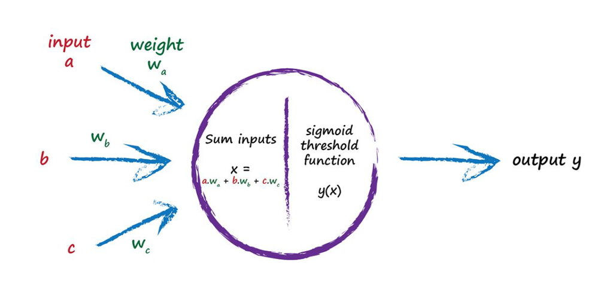

If the combined signal is not large enough then the effect of the sigmoid threshold function is to suppress the output signal. If the sum x if large enough the effect of the sigmoid is to fire the neuron. Interestingly, if only one of the several inputs is large and the rest small, this may be enough to fire the neuron. What’s more, the neuron can fire if some of the inputs are individually almost, but not quite, large enough because when combined the signal is large enough to overcome the threshold. A neural network is just a network consisting of multiple artificial neurons interconnected with weighted links.

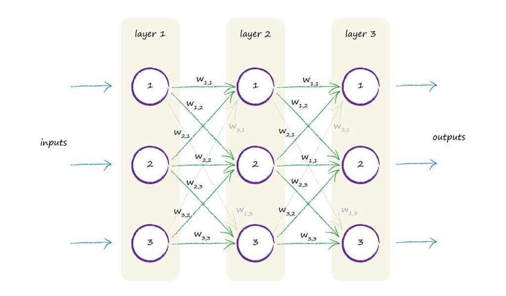

The outputs of a neural network can be written in terms of inputs and weights which is illustrated as follows.

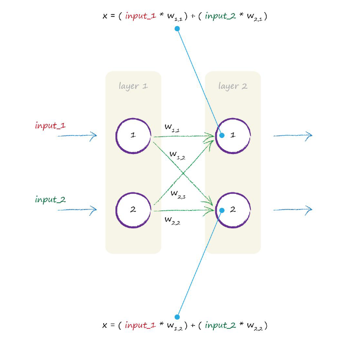

Key Points:

- The many calculations needed to feed a signal forward through a neural network can be expressed as matrix multiplication.
- Expressing it as matrix multiplication makes it much more concise for us to write, no matter the size of neural network.

# Making a neural network : Activation Functions

As we have introducted activation functions, lets use pytorch to use them.

```python
# generate some fake data
x = torch.linspace(-5, 5, 200)  # x data (tensor), shape=(200, 1)
x_np = x.data.numpy()   # numpy array for plotting
```

```python
# following are some common activation functions
y_relu = F.relu(x).data.numpy()
y_sigmoid = torch.sigmoid(x).data.numpy()
y_tanh = torch.tanh(x).data.numpy()
y_softplus = F.softplus(x).data.numpy()

# y_softmax = F.softmax(x)
# softmax is a special kind of activation function, it is about probability
# and will make the sum as 1.
```

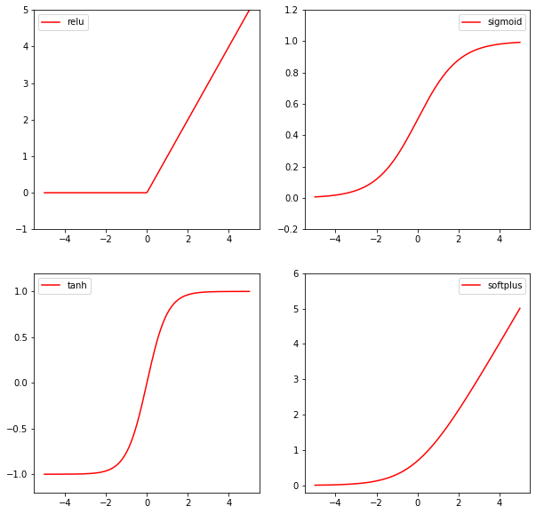

```python
# plot these activation functions
plt.figure(1,(10,10))

plt.subplot(221)
plt.plot(x_np, y_relu, c='red', label='relu')
plt.ylim((-1, 5))
plt.legend(loc='best')

plt.subplot(222)
plt.plot(x_np, y_sigmoid, c='red', label='sigmoid')
plt.ylim((-0.2, 1.2))
plt.legend(loc='best')

plt.subplot(223)
plt.plot(x_np, y_tanh, c='red', label='tanh')
plt.ylim((-1.2, 1.2))
plt.legend(loc='best')

plt.subplot(224)
plt.plot(x_np, y_softplus, c='red', label='softplus')
plt.ylim((-0.2, 6))
plt.legend(loc='best')

plt.show()
```

# Making a neural network : Autograd

To train the weights of a neural network, we backpropagate the error to minimize the cost between the output of the neural network and training data. This is illustrated in the figure.

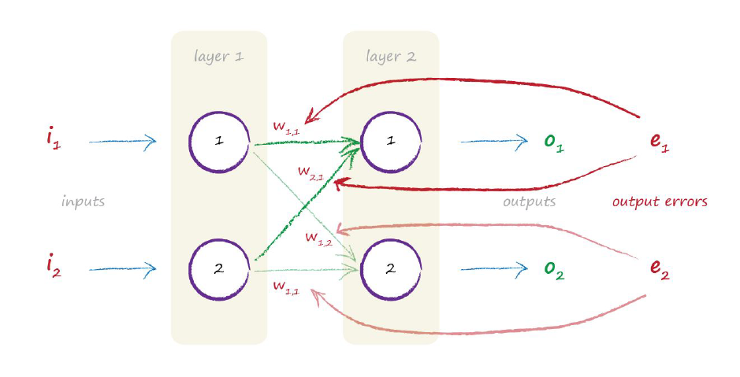

Like feed-forward path, we can also do back propagation using matrix multiplication. We can manually implement both the forward and backward passes of our neural network. Manually implementing the backward pass is not a big deal for a small two-layer network, but can quickly get very hairy for large complex networks.

Thankfully, we can use automatic differentiation to automate the computation of backward passes in neural networks. The autograd package in PyTorch provides exactly this functionality. To make use of autograd, we have set the parameter `requires_grad=True` when we initialize a tensor. This allows automatic gradient computation on the tensor when the .backward() function is called. The object contains the data of the tensor, the gradient of the tensor (once computed with respect to some other value i.e. the loss) and also contains a reference to whatever function created the variable (if it is a user created function, this reference will be null).

Let’s create a simple tensor to demonstrate autograd:

```python
x =  torch.tensor(2.0, requires_grad=True)
print(x)
```

```
tensor(2., requires_grad=True)
```

If we were using this in a neural network, this would mean that this tensor would be trainable. If we set this `requires_grad` to False, the tensor would not be trained. Next, let’s create another tensor, constructed based on operations on our original tensor $x$.

$$z = 2x^2 + 5x$$

```python
z =   2 * (x **2) + 5 * x
print(z)
```

```
tensor(18., grad_fn=<AddBackward0>)
```

The gradient of this operation with respect to x: $\frac{dz}{dx} = 4x +5.$ If $ x = 2 $, then we should expect $\frac{dz}{dx} =13$.

When backward function for output tensor (e.g. `z.backward()`) is called, the function will perform backpropogration and calculate the gradient with respect to each tensor that is connected to output tensor , whose `requires_grad=True`. This gradient value is stored in the grad attribute of that tensor (e.g. `x.grad`). After calling the backward function, we can print the calculated gradient using grad attribute of the tensor.

```python
z.backward()

print('Derivative of z with respective to x =',x.grad )
```

```
Derivative of z with respective to x = tensor(13.)
```

# Making a neural network : optimizers

In order to minimize a cost function, we use an optimization algorithm that does it for us. Most common optimization algorithm is the stochastic gradient descent, however there are different algorithms that can be used. We use the optim package to define an Optimizer that will update the weights for us. The optim package defines many optimization algorithms that are commonly used for deep learning, including SGD+momentum, RMSProp, Adam, etc.

### Dataset used for demonstration

$$ y = x^2 + (0.1 \times e); \quad x\in [-1,1] ,\ e \in \mathcal{N}(0,1) $$

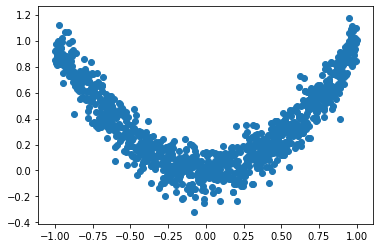

```python
torch.manual_seed(1)    # reproducible

LR = 0.01
BATCH_SIZE = 128#32
EPOCH = 12

# dataset
x = torch.unsqueeze(torch.linspace(-1, 1, 1000), dim=1)
y = x.pow(2) + 0.1*torch.normal(mean=torch.zeros(*x.size()),std=1)

# plot dataset
plt.scatter(x.numpy(), y.numpy())
plt.show()
```

```python
# Load the data
torch_dataset = Data.TensorDataset(x,y)
loader = Data.DataLoader(
    dataset=torch_dataset,
    batch_size=BATCH_SIZE,
    shuffle=True, num_workers=2,)
```

```python
class Net(torch.nn.Module):
    def __init__(self):
        super(Net, self).__init__()
        self.hidden = torch.nn.Linear(1, 20)   # hidden layer
        self.predict = torch.nn.Linear(20, 1)   # output layer

    def forward(self, x):
        x = F.relu(self.hidden(x))      # activation function for hidden layer
        x = self.predict(x)             # linear output
        return x
```

In the example given below, we shall train **4 neural networks** with the **same network architecture** but **different optimizer**.

```python
net_SGD         = Net()
net_Momentum    = Net()
net_RMSprop     = Net()
net_Adam        = Net()
nets = [net_SGD, net_Momentum, net_RMSprop, net_Adam]
```

```python
opt_SGD         = torch.optim.SGD(net_SGD.parameters(), lr=LR)
opt_Momentum    = torch.optim.SGD(net_Momentum.parameters(), lr=LR, momentum=0.8)
opt_RMSprop     = torch.optim.RMSprop(net_RMSprop.parameters(), lr=LR, alpha=0.9)
opt_Adam        = torch.optim.Adam(net_Adam.parameters(), lr=LR, betas=(0.9, 0.99))
optimizers = [opt_SGD, opt_Momentum, opt_RMSprop, opt_Adam]
```

```python
loss_func = torch.nn.MSELoss()
losses_his = [[], [], [], []]   # for storing loss from each network

# training
for net, opt, l_his in zip(nets, optimizers, losses_his):
    for epoch in range(EPOCH):
        for step, (batch_x, batch_y) in enumerate(loader):          # for each training step

            output = net(batch_x)              # get output for every net
            loss = loss_func(output, batch_y)  # compute loss for every net
            opt.zero_grad()                # clear gradients for next train batch
            loss.backward()                # backpropagation, compute gradients
            opt.step()                     # apply gradients
            l_his.append(loss)             # store the loss
```

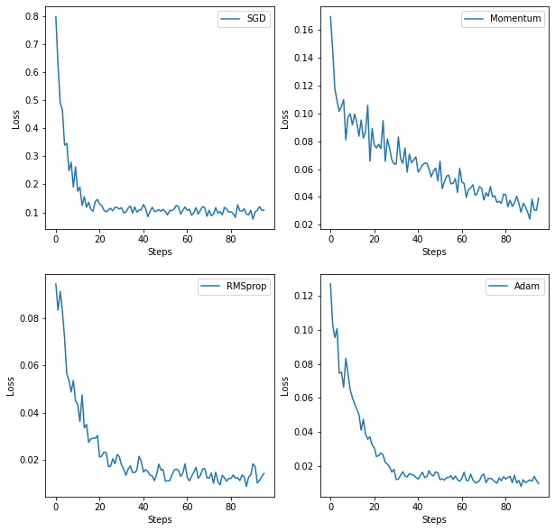

```python
plt.figure(1,(10,10))
labels = ['SGD', 'Momentum', 'RMSprop', 'Adam']
for i in range(4):

    # The matplotlib plot function accepts numpy arrays as input.
    # Before converting to numpy, we turn off the gradient calculation by using detach()
    # In case the array is loaded in the GPU (cuda device), the array needs to be loaded
    # back to the CPU.

    loss = torch.tensor(losses_his[i]).detach().cpu().numpy()

    label = labels[i]
    plt.subplot(221+i)
    plt.plot(loss, label=label)
    plt.legend(loc='best')
    plt.xlabel('Steps')
    plt.ylabel('Loss')



plt.show()
```

# Making a neural network for MNIST

Lets use what we have learnt so far to train a neural network to recognize handwritten digits from MNIST data_set. We will create a simple 3 layer neural network that is illustrated in the figure below

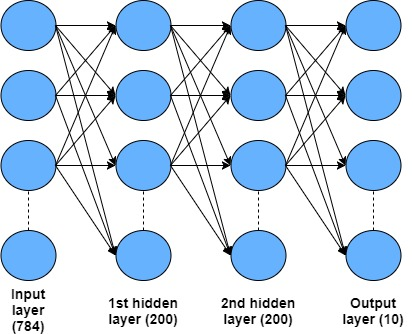

We will train this network and analyze its performance.

For simpler networks the layers can be manually connected. But pytorch makes arranging neurons and making layers easier. The nn package defines a set of Modules, which are roughly equivalent to neural network layers. A Module receives input Tensors and computes output Tensors, but may also hold internal state such as Tensors containing learnable parameters. The nn package also defines a set of useful loss functions that are commonly used when training neural network.

In order to create a neural network in PyTorch, we can inherit this class, this basically allows us to use all of the functionality of the nn.Module base class, but still have overwriting capabilities of the base class for the model construction / forward pass through the network.

NOTE: please read about inheritance in python if unfamiliar.

```python
class Net(nn.Module):
    def __init__(self):
        super(Net, self).__init__()
        self.fc1 = nn.Linear(28 * 28, 200)
        self.fc2 = nn.Linear(200, 200)
        self.fc3 = nn.Linear(200, 10)

    def forward(self, x):
        x = F.relu(self.fc1(x))
        x = F.relu(self.fc2(x))
        x = self.fc3(x)
        return F.log_softmax(x,dim=1)
```

Set hyper parameters.

```python
batch_size=200
learning_rate=0.01
epochs=10
log_interval=100
```

Load the MNIST data set.

```python
train_loader = torch.utils.data.DataLoader(
    datasets.MNIST('../data', train=True, download=True,
                   transform=transforms.Compose([
                   transforms.ToTensor(),
                   transforms.Normalize((0.1307,), (0.3081,))
                       ])),
        batch_size=batch_size, shuffle=True)


test_loader = torch.utils.data.DataLoader(
    datasets.MNIST('../data', train=False, transform=transforms.Compose([
        transforms.ToTensor(),
        transforms.Normalize((0.1307,), (0.3081,))
        ])),
        batch_size=batch_size, shuffle=True)
```

```
Downloading http://yann.lecun.com/exdb/mnist/train-images-idx3-ubyte.gz to ../data/MNIST/raw/train-images-idx3-ubyte.gz
```

```
Extracting ../data/MNIST/raw/train-images-idx3-ubyte.gz to ../data/MNIST/raw
Downloading http://yann.lecun.com/exdb/mnist/train-labels-idx1-ubyte.gz to ../data/MNIST/raw/train-labels-idx1-ubyte.gz
```

```
Extracting ../data/MNIST/raw/train-labels-idx1-ubyte.gz to ../data/MNIST/raw
Downloading http://yann.lecun.com/exdb/mnist/t10k-images-idx3-ubyte.gz to ../data/MNIST/raw/t10k-images-idx3-ubyte.gz
```

```
Extracting ../data/MNIST/raw/t10k-images-idx3-ubyte.gz to ../data/MNIST/raw
Downloading http://yann.lecun.com/exdb/mnist/t10k-labels-idx1-ubyte.gz to ../data/MNIST/raw/t10k-labels-idx1-ubyte.gz
```

```
Extracting ../data/MNIST/raw/t10k-labels-idx1-ubyte.gz to ../data/MNIST/raw
Processing...
Done!
```

Show the net.

```python
net = Net()
print(net)
```

```
Net(
  (fc1): Linear(in_features=784, out_features=200, bias=True)
  (fc2): Linear(in_features=200, out_features=200, bias=True)
  (fc3): Linear(in_features=200, out_features=10, bias=True)
)
```

Set the loss function and the optimization criteria

```python
# create a stochastic gradient descent optimizer
optimizer = optim.SGD(net.parameters(), lr=learning_rate, momentum=0.9)
# create a loss function
criterion = nn.NLLLoss()
```

Run the main loop to train the network

```python
# run the main training loop
for epoch in range(epochs):
    total_loss = 0.0
    for batch_idx, (data, target) in enumerate(train_loader):
        # resize data from (batch_size, 1, 28, 28) to (batch_size, 28*28)
        data = data.view(-1, 28*28)
        optimizer.zero_grad()
        net_out = net(data)
        loss = criterion(net_out, target)
        total_loss+=loss.data
        loss.backward()
        optimizer.step()
        if batch_idx and batch_idx % log_interval == 0:
            print('Train Epoch: {} [{}/{} ({:.0f}%)]\tLoss: {:.6f}'.format(
                epoch+1, batch_idx * len(data), len(train_loader.dataset),
                100. * batch_idx / len(train_loader), loss.data))
    print('Train Epoch: {} Avg. Training Loss: {:.6f}\n'.format(
                epoch+1,
                total_loss/len(train_loader.dataset)))
```

```
Train Epoch: 1 [20000/60000 (33%)]	Loss: 0.337117
Train Epoch: 1 [40000/60000 (67%)]	Loss: 0.242781
Train Epoch: 1 Avg. Training Loss: 0.002730

Train Epoch: 2 [20000/60000 (33%)]	Loss: 0.232903
Train Epoch: 2 [40000/60000 (67%)]	Loss: 0.175857
Train Epoch: 2 Avg. Training Loss: 0.000995

Train Epoch: 3 [20000/60000 (33%)]	Loss: 0.246690
Train Epoch: 3 [40000/60000 (67%)]	Loss: 0.144103
Train Epoch: 3 Avg. Training Loss: 0.000705

Train Epoch: 4 [20000/60000 (33%)]	Loss: 0.182926
Train Epoch: 4 [40000/60000 (67%)]	Loss: 0.125164
Train Epoch: 4 Avg. Training Loss: 0.000533

Train Epoch: 5 [20000/60000 (33%)]	Loss: 0.073721
Train Epoch: 5 [40000/60000 (67%)]	Loss: 0.057277
Train Epoch: 5 Avg. Training Loss: 0.000429

Train Epoch: 6 [20000/60000 (33%)]	Loss: 0.098754
Train Epoch: 6 [40000/60000 (67%)]	Loss: 0.084686
Train Epoch: 6 Avg. Training Loss: 0.000353

Train Epoch: 7 [20000/60000 (33%)]	Loss: 0.043468
Train Epoch: 7 [40000/60000 (67%)]	Loss: 0.033740
Train Epoch: 7 Avg. Training Loss: 0.000286

Train Epoch: 8 [20000/60000 (33%)]	Loss: 0.043044
Train Epoch: 8 [40000/60000 (67%)]	Loss: 0.076855
Train Epoch: 8 Avg. Training Loss: 0.000243

Train Epoch: 9 [20000/60000 (33%)]	Loss: 0.069460
Train Epoch: 9 [40000/60000 (67%)]	Loss: 0.030850
Train Epoch: 9 Avg. Training Loss: 0.000207

Train Epoch: 10 [20000/60000 (33%)]	Loss: 0.028261
Train Epoch: 10 [40000/60000 (67%)]	Loss: 0.038884
Train Epoch: 10 Avg. Training Loss: 0.000175
```

Run the testing loop

```python
test_loss = 0.0
correct = 0.0

for data, target in test_loader:
    data = data.view(-1, 28 * 28)
    net_out = net(data)
    # sum up batch loss
    test_loss += criterion(net_out, target).data
    pred = net_out.data.max(1)[1]  # get the index of the max log-probability
    correct += pred.eq(target.data).sum()

test_loss /= len(test_loader.dataset)
print('\nTest set: Average loss: {:.4f}, Accuracy: {:.0f}/{} ({:.2%})\n'.format(
    test_loss, correct, len(test_loader.dataset),correct / len(test_loader.dataset)))
```

```
Test set: Average loss: 0.0004, Accuracy: 9769/10000 (97.69%)
```

# EXERCISES

1) Look for a way to save the network that you trained and load it back. Verify that you get the same accuracy on the test dataset when you load the saved model.

2) Create a CNN to perform the same task in the previous task. Use the network architecture from the Exercise 3.2 of the previous lab task (Theory of deep learning). Note: Unlike the previous example in this tutorial, the each input image to the CNN will now be represented in 2D.